# Drill - Describing Data

```python
import numpy as np
import pandas as pd
import matplotlib.pyplot as plt
import statistics
%matplotlib inline
```

Greg was 14, Marcia was 12, Peter was 11, Jan was 10, Bobby was 8, and Cindy was 6 when they started playing the Brady kids on The Brady Bunch. Cousin Oliver was 8 years old when he joined the show. What are the mean, median, and mode of the kids' ages when they first appeared on the show? What are the variance, standard deviation, and standard error?

```python
#Creating the dataframe
data = [['Greg',14],['Marcia',12],['Peter',11],['Jan', 10],['Bobby',8],['Cindy',6],['Oliver',8]]
df = pd.DataFrame(data,columns=['Name','Age'])
print (df)
```

```
     Name  Age
0    Greg   14
1  Marcia   12
2   Peter   11
3     Jan   10
4   Bobby    8
5   Cindy    6
6  Oliver    8
```

```python
#Calculating the mean age; mean = average variable
np.mean(df['Age'])
```

```
9.857142857142858
```

```python
#Calculating the median age; median = middle variable
np.median(df['Age'])
```

```
10.0
```

```python
#Calculating the mode age; mode = value in a variable that occurs most frequently
statistics.mode(df['Age'])
```

```
8
```

```python
#Calculating the variance in age; variance = how much values differ from central tendency
np.var(df.Age)
```

```
6.408163265306122
```

```python
#Calculating the standard deviation; most common estimate of variability
np.std(df['Age'], ddof=1)
```

```
2.734262327610589
```

```python
#standard error follows; quantifies uncertainty in the estimate of the sample mean
np.std(df['Age'] ,ddof=1) / np.sqrt(len(df['Age']))
```

```
1.0334540197243192
```

Using these estimates, if you had to choose only one estimate of central tendency and one estimate of variance to describe the data, which would you pick and why? Central tendency = mean; I believe it gives a whole estimate of the age ranges taking into account all of the range Variance = standard deviation; it's an estimate of variability

[figure not shown]

```python
df.hist()
plt.title("Brady Bunch Child Actor's Ages")
plt.xlabel("Range of Ages")
plt.ylabel("Occurances of Ages")
plt.show()
```

Next, Cindy has a birthday. Update your estimates- what changed, and what didn't?

```python
#Creating the dataframe
data = [['Greg',14],['Marcia',12],['Peter',11],['Jan', 10],['Bobby',8],['Cindy',7],['Oliver',8]]
df = pd.DataFrame(data,columns=['Name','Age'])
print (df)
```

```
     Name  Age
0    Greg   14
1  Marcia   12
2   Peter   11
3     Jan   10
4   Bobby    8
5   Cindy    7
6  Oliver    8
```

```python
#Calculating the mean age; mean = average variable
np.mean(df['Age'])
```

```
10.0
```

```python
#Calculating the median age; median = middle variable
np.median(df['Age'])
```

```
10.0
```

```python
#Calculating the mode age; mode = value in a variable that occurs most frequently
statistics.mode(df['Age'])
```

```
8
```

```python
#Calculating the variance in age; variance = how much values differ from central tendency
np.var(df.Age)
```

```
5.428571428571429
```

```python
#Calculating the standard deviation; most common estimate of variability
np.std(df['Age'], ddof=1)
```

```
2.516611478423583
```

```python
#standard error follows; quantifies uncertainty in the estimate of the sample mean
np.std(df['Age'] ,ddof=1) / np.sqrt(len(df['Age']))
```

```
0.9511897312113418
```

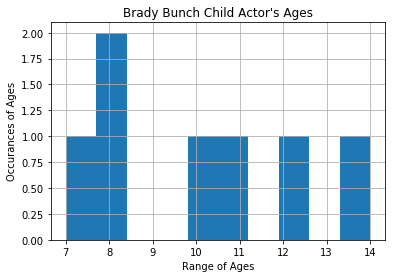

```python
df.hist()
plt.title("Brady Bunch Child Actor's Ages")
plt.xlabel("Range of Ages")
plt.ylabel("Occurances of Ages")
plt.show()
```

Nobody likes Cousin Oliver. Maybe the network should have used an even younger actor. Replace Cousin Oliver with 1-year-old Jessica, then recalculate again. Does this change your choice of central tendency or variance estimation methods?

```python
#Creating the dataframe
data = [['Greg',14],['Marcia',12],['Peter',11],['Jan', 10],['Bobby',8],['Cindy',7],['Jessica',1]]
df = pd.DataFrame(data,columns=['Name','Age'])
print (df)
```

```
      Name  Age
0     Greg   14
1   Marcia   12
2    Peter   11
3      Jan   10
4    Bobby    8
5    Cindy    7
6  Jessica    1
```

```python
df.describe()
```

|  | Age |
| --- | --- |
| count | 7.000000 |
| mean | 9.000000 |
| std | 4.242641 |
| min | 1.000000 |
| 25% | 7.500000 |
| 50% | 10.000000 |
| 75% | 11.500000 |
| max | 14.000000 |

```python
#Calculating the median age; median = middle variable
np.median(df['Age'])
```

```
10.0
```

```python
#Calculating the mode age; mode = value in a variable that occurs most frequently
statistics.mode(df['Age'])
```

[output not shown]

```python
#Calculating the variance in age; variance = how much values differ from central tendency
np.var(df.Age)
```

```
15.428571428571429
```

```python
#standard error follows; quantifies uncertainty in the estimate of the sample mean
np.std(df['Age'] ,ddof=1) / np.sqrt(len(df['Age']))
```

```
1.6035674514745462
```

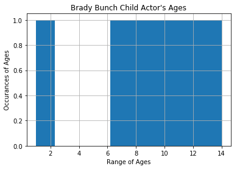

```python
df.hist()
plt.title("Brady Bunch Child Actor's Ages")
plt.xlabel("Range of Ages")
plt.ylabel("Occurances of Ages")
plt.show()
```

On the 50th anniversary of The Brady Bunch, four different magazines asked their readers whether they were fans of the show. The answers were: TV Guide 20% fans Entertainment Weekly 23% fans Pop Culture Today 17% fans SciPhi Phanatic 5% fans

Based on these numbers, what percentage of adult Americans would you estimate were Brady Bunch fans on the 50th anniversary of the show?

```python
#Creating the dataframe
magazine_data = [['TV Guide',20],['Entertainment Weekly',23],['Pop Culture Today',17],['SciPhi Phanatic', 5]]
magazine_df = pd.DataFrame(magazine_data,columns=['Name of Magazine','Percentage Fans'])
print (magazine_df)
```

```
       Name of Magazine  Percentage Fans
0              TV Guide               20
1  Entertainment Weekly               23
2     Pop Culture Today               17
3       SciPhi Phanatic                5
```

```python
magazine_df.describe()
```

|  | Percentage Fans |
| --- | --- |
| count | 4.000000 |
| mean | 16.250000 |
| std | 7.889867 |
| min | 5.000000 |
| 25% | 14.000000 |
| 50% | 18.500000 |
| 75% | 20.750000 |
| max | 23.000000 |

```python
#standard error follows; quantifies uncertainty in the estimate of the sample mean
np.std(magazine_df['Percentage Fans'] ,ddof=1) / np.sqrt(len(magazine_df['Percentage Fans']))
```

```
3.944933459514875
```

I would estimate that approx 16% of Americans were fans of the show. However, the margin of error is 4%, which is pretty wide.